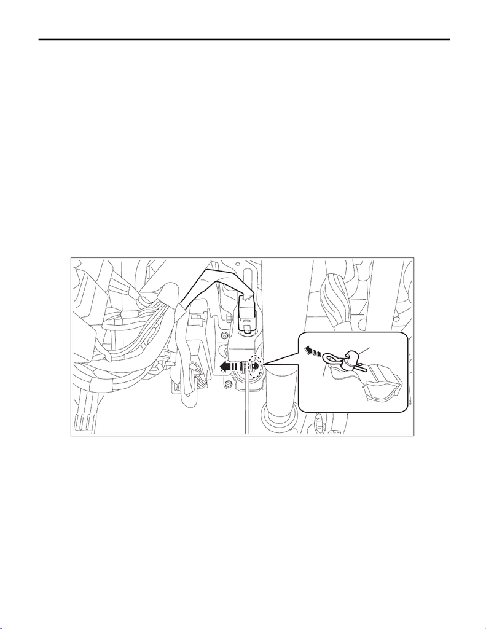

BR-73

Brake Pedal

BRAKE

14.Brake Pedal

A: REMOVAL

1. CVT MODEL

CAUTION:

Before performing service on the airbag module, always refer to “CAUTION” of “General Descrip-

tion” in “AIRBAG SYSTEM” section. <Ref. to AB-9, CAUTION, General Description.>

1) Disconnect the ground cable from battery and wait for at least 60 seconds before starting work. <Ref. to

NT-5, BATTERY, NOTE, Note.>

2) Remove the cover assembly - instrument panel LWR driver. <Ref. to EI-61, REMOVAL, Instrument Panel

Lower Cover.>

3) Remove the knee airbag module. <Ref. to AB-35, REMOVAL, Knee Airbag Module.>

4) Remove the column assembly - steering. <Ref. to PS-25, REMOVAL, Steering Column.>

5) Remove the brake pedal assembly.

(1) Disconnect the stop light switch connector.

(2) Remove the snap pin (a) and clevis pin (b), and remove the operating rod from the brake pedal.

CAUTION:

• Be careful not to apply excessive force to the operating rod when handling the operating rod.

The angle may change by ±3°, and it may result in damage to power piston cylinder.

• Do not change the push rod length.

(a)

(b)

BR-01213

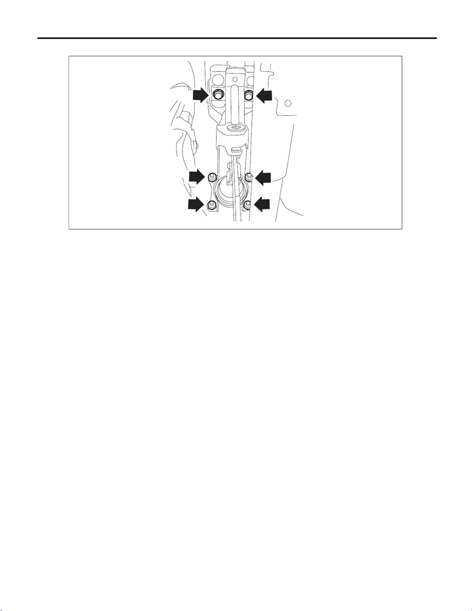

BR-74

Brake Pedal

BRAKE

(3) Remove the bolt and nut, and then detach the brake pedal assembly.

2. MT MODEL

NOTE:

Brake pedal is integrated with the clutch pedal.

For removal procedures of the brake pedal, refer to Clutch section. <Ref. to CL-31, REMOVAL, Clutch Ped-

al.>

B: INSTALLATION

1. CVT MODEL

CAUTION:

Before performing service on the airbag module, always refer to “CAUTION” of “General Descrip-

tion” in “AIRBAG SYSTEM” section. <Ref. to AB-9, CAUTION, General Description.>

1) Install the brake pedal assembly.

CAUTION:

• Apply grease to the snap pin to prevent the operating rod from wear.

• Replace the clevis pin with new parts, and apply thin coat of NIGTIGHT LYW No. 2 grease to the cle-

vis pin.

Tightening torque:

Brake pedal: 18 N·m (1.8 kgf-m, 13.3 ft-lb)

2) Install the column assembly - steering. <Ref. to PS-28, INSTALLATION, Steering Column.>

3) Install the knee airbag module.

Tightening torque:

7.5 N·m (0.8 kgf-m, 5.5 ft-lb)

4) Install the cover assembly - instrument panel LWR driver.

5) Connect the battery ground terminal. <Ref. to NT-5, BATTERY, NOTE, Note.>

NOTE:

For models other than STI model, connect the ground terminal to battery sensor.

6) Check that the brake light operate properly.

7) Check the brake pedal after installation. <Ref. to BR-75, INSPECTION, Brake Pedal.>

BR-00971

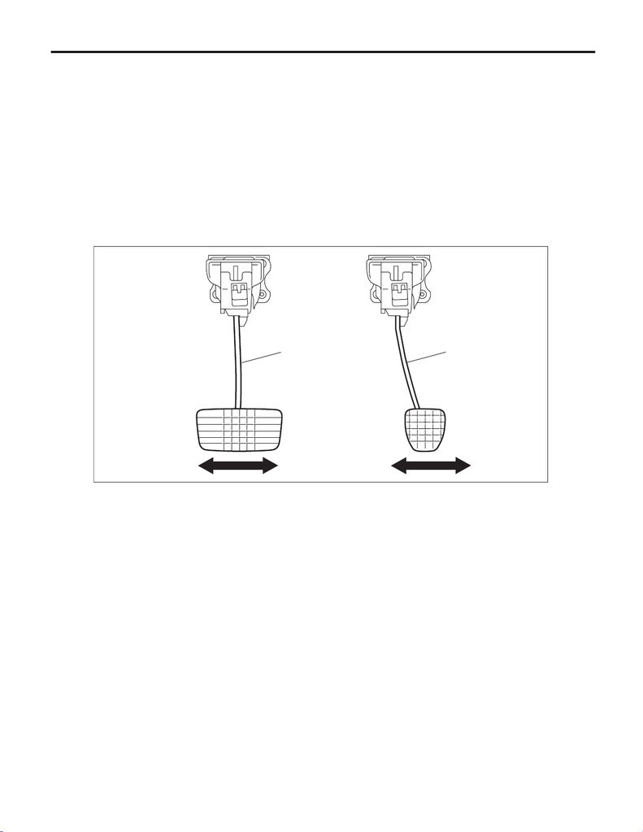

BR-75

Brake Pedal

BRAKE

2. MT MODEL

NOTE:

Brake pedal is integrated with the clutch pedal.

For installation procedure of the brake pedal, refer to Clutch section. <Ref. to CL-31, INSTALLATION, Clutch

Pedal.>

C: INSPECTION

1) Move the pad - brake pedal in a horizontal direction with a force of approx. 10 N (1 kgf, 2 lbf), and check

that the pedal deflection is in the range of specifications.

CAUTION:

If excessive deflection is noted, replace with a new bushing.

Deflection of brake pedal:

Wear limit: 5.0 mm (0.197 in) or less

(a) Brake pedal (CVT model) (b) Brake pedal (MT model)

(a)

(b)

BR-00959

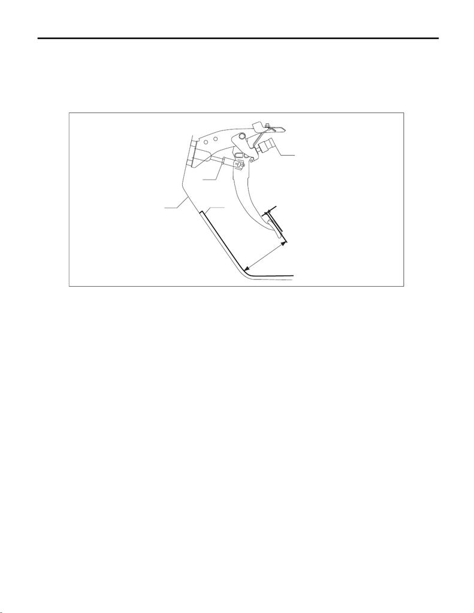

BR-76

Brake Pedal

BRAKE

2) Check the position of the pedal pad.

Pedal height L:

140 — 150 mm (5.51 — 5.91 in)

Brake pedal free play A:

0.5 — 2 mm (0.020 — 0.079 in) [When pulling the brake pedal upward with a force of less than 10 N

(1 kgf, 2 lbf).]

3) If it is not within the specification, loosen the lock nuts of vacuum booster operating rod, and rotate the rod

to adjust the pedal height L within the specification.

4) Tighten the lock nut.

Tightening torque:

Operating lock nut: 22 N·m (2.2 kgf-m, 16.2 ft-lb)

NOTE:

Check the brake pedal height. When adjusting, also adjust the stop light switch.

(a) Stop light switch (c) Toe board (d) Brake booster operating rod

(b) Mat

(a)

(b)

(c)

(d)

L

A

BR-00960